# **I. ICC Data Cleaning and Preprocessing**

This notebook is for ICC data preprocessing before training bayesian network.

Variables and values determined in an expert interview:

1. **age at beginning medication**: <16, 16-24, 24-60, >60
   - calculate age first visit - birthyear. divide categories
2. **gender**: male, female
3. **disease location at diagnosis**: ileum, colon, both
   - D_MON_LOC_CD. 1, 2, 3, 4, 5, 6.
   - ileum = 1, 4 colon: 2, 6 both: 3, 5
4. **disease location at inclusion**: ileum, colon, both
   - W1_MON_LOC_CD_INC. 1, 2, 3, 4, 5, 6.
   - ileum = 1, 4 colon: 2, 6 both: 3, 5
5. **disease behavior at diagnosis**: inflammatory, stricturing, penetrating
   - D_MON_BEH_CD. 1, 2, 3
   - inflammatory: 1, stricturing: 2, penetrating: 3
6. **disease behavior at inclusion**: inflammatory, stricturing, penetrating
   - W1_MON_BEH_CD_INC. 1, 2, 3
   - inflammatory: 1, stricturing: 2, penetrating: 3
7. **previous medication**: prednison (corticosteroid), mesalazines (5-ASA), thiopurines, immunomodulators,
8. **anti-TNF** (infliximab, adalimumab, golimumab, certolizumab pegol), anti-leucine 12, anti-interkines, jak-inkibiteren
   - medication history available. check the medications
   - MH_BUD, MH_CORT, MH_5_ASA, MH_THIO, MH_TGN, MH_MTX, MH_IFX, MH_ADA, MH_GOL, MH_CERT, MH_VEDO, MH_USTE, MH_TOFA, MH_O_BIO
   - MH_O_BIO_BIN, MH_O_IMM_BIN, MH_O_IMM
9. **calpro**: <100, 100-250, >250
   - W1_LAB_CAL
10. **CRP**: <10, >10
    - W1_LAB_CRP
11. **medical history**: cancer yes, cancer no
    - different cancer info available. No other medical history.
    - Ever cancer: CM_C_CRC, CM_C_L, CM_C_BR, CM_C_NHL, CM_C_NMSC, CM_C_MSC, CM_C_P, CM_C_CX, CM_C_O
12. **smoking**: never, past, current
    - at inclusion W1_SMOK 1: never, 2: past, 3: current
13. **prior surgery**: yes, no
    - surgeries: MH_CD_PERIAN_SUR, W1_FISTELOK
14. **BMI** (length and weigth): <18.5, 18.5-24.9, 25.0-29.9, >30.0
    - calculate using: W1_HEIGHT, W1_WEIGHT
15. **thrombocytes**: ranges to be determined..
    - W1_LAB_TB
16. **number of comorbidities**: 0, 1, 2, 3....
    - columns indicating presence of a specific comorbidity
    - CM_M_DM, CM_M_HCHOL, CM_IN_HIV, CM_IN_HV, CM_NEU_EP, CM_NEU_MIG, CM_NEU_PAR, CM_HEAR, CM_VIS, CM_CV_AH,
    - CM_CV_CVA, CM_CV_HEARTC, CM_CV_HEARTD, CM_CV_HEARTR, CM_CV_HEARTV, CM_LUNG_ASTMA, CM_LUNG_COPD, CM_SKIN_PS, CM_SKIN_E,
    - CM_RI, CM_ALC_LIV, CM_ALC_O, CM_LM_RA, CM_LM_SPA, CM_LM_OP, CM_LM_PA, CM_LM_CB, CM_IM_C, CM_IM_O, CM_PSY_MR, CM_PSY_DEM,
    - CM_PSY_DR, CM_PSY_ALC, CM_PSY_DEP, CM_PSY_A, CM_PSY_ASS, CM_PSY_ADHD, CM_PSY_B, CM_PSY_P, CM_PSY_BO
17. **disease duration** (in years): <2, 2-5, >5
    - from diagnosis until first visit date
18. **age at diagnosis**: <16, 16-24, 24-60, >60
    - calculate birthyear and diagnosis date D_DATE
19. **apendectomy**: yes, no
    - MH_AP_UC
20. **extraintestinal manifestations**: yes, no

variables used in DEDUCE: age, HBI at baseline, steroids at baseline, treatmetn, prior surgery, CRP, disease duration.

disease behavior, current smoker, gender, number of prior TNFs. These were selcted by RFE algorithms (LR, RF, SVM, XgBoost)

```python
import pandas as pd
import numpy as np
import matplotlib.pyplot as plt
from sklearn.model_selection import train_test_split
from datetime import date
import re
import seaborn as sns
from scipy import stats
```

## 1. Read raw data

```python
# 1. Read raw data
icc_raw = pd.read_excel("ICC_CD.xlsx")
```

## 2. Handle null and placeholder values

```python
# create dataframe for clean icc data
icc_clean = pd.DataFrame(icc_raw)

# 2. Handle null and placeholder values
null_values = ['#NULL!', '99', 99]
icc_clean.replace(null_values, np.nan, inplace=True)

# Remove columns with all null values
null_columns  = icc_clean.columns[icc_clean.isnull().all()]
icc_clean.drop(columns=null_columns, inplace=True)
```

## 3. Exclude irrelevant visit columns and specific columns

```python
# 3. Exclude irrelevant visit columns and specific columns

# exclude columns W2, W3, W5, W6 . Because they are not relevant for this analysis.
# Predictor variables are on W1 or before (D) and outcome on W4
# exclude other columns: D_FIRSTFISTEL_DATE

visit_cols = [col for col in icc_clean.columns if any(w in col for w in ['W2', 'W3', 'W5', 'W6', 'WE6'])]
exclude_cols = visit_cols + ['D_FIRSTFISTEL_DATE']
icc_clean.drop(columns=exclude_cols, inplace=True)
```

## 4. Date preprocessing with robust error handling

```python
def clean_dates(df):
    # Specific error corrections
    date_corrections = {
        14540: {'W4_PLANVISDAT': '2019-08-28'},
        17783: {'D_DATE': np.nan}
        }
    for respnr, corrections in date_corrections.items():
        for col, value in corrections.items():
            df.loc[df['RESPNR'] == respnr, col] = pd.to_datetime(value)
    # Convert date columns
    date_cols = df.select_dtypes(include=['object']).columns
    for col in date_cols:
        if 'DAT' in col:
            df[col] = pd.to_datetime(df[col], errors='coerce')

    # Remove future dates
    today = pd.to_datetime(date.today())
    date_columns = df.select_dtypes(include=['datetime64']).columns
    for col in date_columns:
        df.loc[df[col] > today, col] = np.nan

    return df

icc_clean = clean_dates(icc_clean)
```

## 5. Numeric conversion with advanced cleaning

```python
def clean_and_convert(value):
    """
    Robust numeric conversion function
    - Removes non-numeric characters
    - Handles comma and period as decimal separators
    - Converts to float with error handling
    """
    if pd.isna(value):
        return np.nan

    # Remove non-numeric characters except periods and commas
    cleaned = re.sub(r'[^\d.,]', '', str(value))

    # Replace comma with period for decimal
    cleaned = cleaned.replace(',', '.')

    try:
        return float(cleaned)
    except ValueError:
        return np.nan

# Apply to specific columns
numeric_cols = ['W1_LAB_CRP', 'W4_LAB_CRP', 'W1_LAB_CAL', 'W4_LAB_CAL']
for col in numeric_cols:
    icc_clean[col] = icc_clean[col].apply(clean_and_convert)
```

## 6. Special case handling

```python
# 6. Special case handling
# Correct specific data anomalies
special_cases = {
    18280: {'BIRTHYEAR': np.nan}
}

for respnr, corrections in special_cases.items():
    for col, value in corrections.items():
        icc_clean.loc[icc_clean['RESPNR'] == respnr, col] = value
```

## 7. Filter for specific medications

```python
# 7. Filter for specific medications
target_medications = [180, 202, 290]  # Ustekinumab, Vedolizumab
icc_clean = icc_clean[icc_clean['MEDICINE'].isin(target_medications)]
```

## 8. Final data validation and cleaning

```python
icc_clean.W1_HB_ARTHRITIS.sum()
```

```
0.0
```

```python
# 8. Final data validation and cleaning
null_columns  = icc_clean.columns[icc_clean.isnull().all()]
icc_clean.drop(columns=null_columns, inplace=True)

icc_clean.reset_index(drop=True, inplace=True)
```

```python
# Create output directory
import os
os.makedirs('icc_analysis', exist_ok=True)
#save the cleaned data To csv file
icc_clean.to_csv("icc_analysis/cleaned_icc_data.csv", index=False)
```

# **II. ICC Data Analysis and Visualization**

Comprehensive analysis of ICC dataset with visualizations

```
Starting analysis...

Analyzing numeric variables...
```

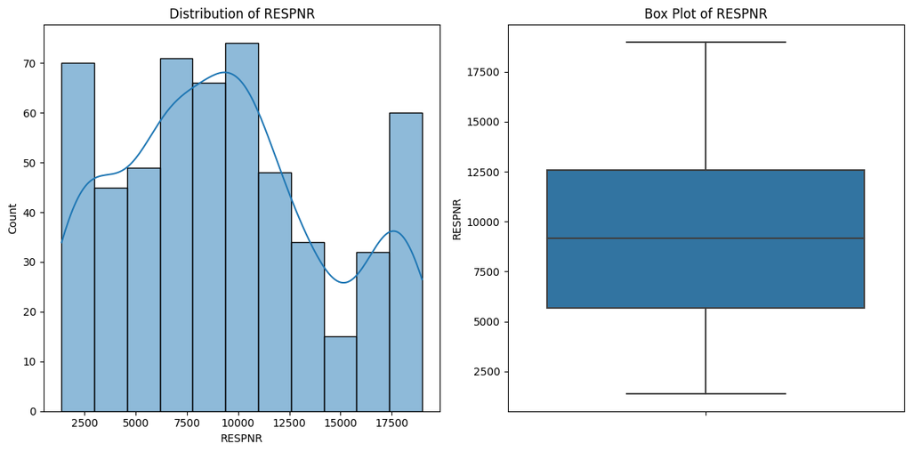

```
Statistics for RESPNR:
Count: 564
Missing: 0
Mean: 9324.28
Median: 9150.00
Std: 5030.62
Min: 1383
Max: 18980
```

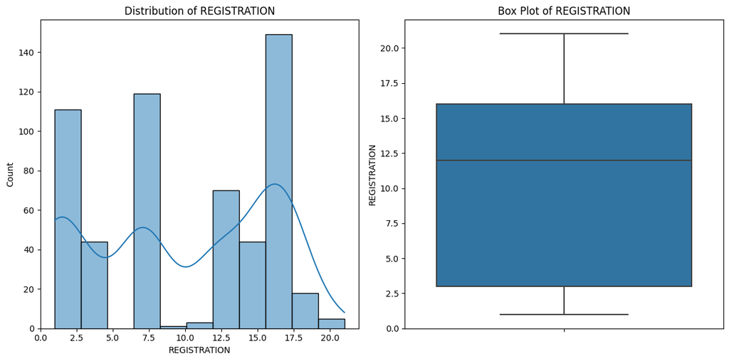

```
Statistics for REGISTRATION:
Count: 564
Missing: 0
Mean: 9.80
Median: 12.00
Std: 6.16
Min: 1.00
Max: 21.01
```

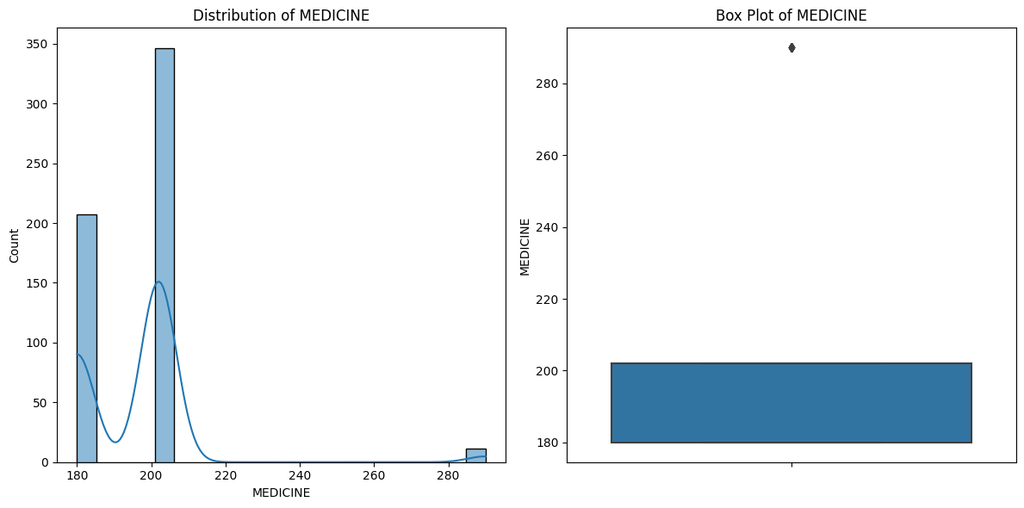

```
Statistics for MEDICINE:
Count: 564
Missing: 0
Mean: 195.64
Median: 202.00
Std: 16.99
Min: 180
Max: 290
```

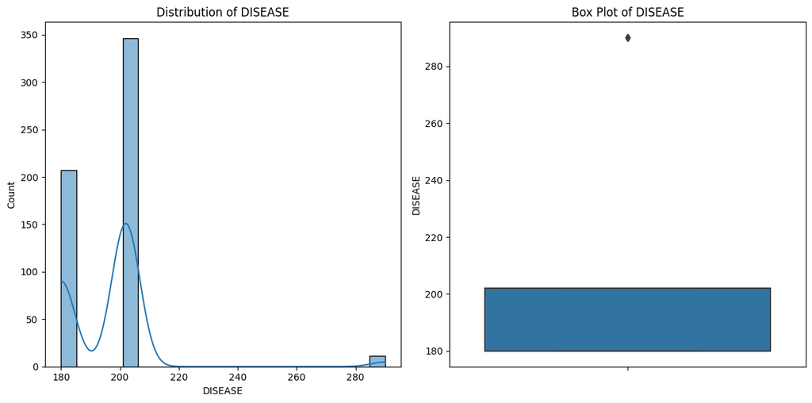

```
Statistics for DISEASE:
Count: 564
Missing: 0
Mean: 195.64
Median: 202.00
Std: 16.99
Min: 180
Max: 290
```

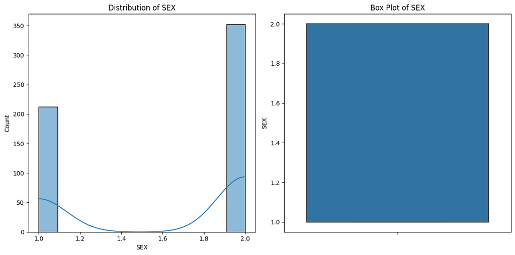

```
Statistics for SEX:
Count: 564
Missing: 0
Mean: 1.62
Median: 2.00
Std: 0.48
Min: 1
Max: 2
```

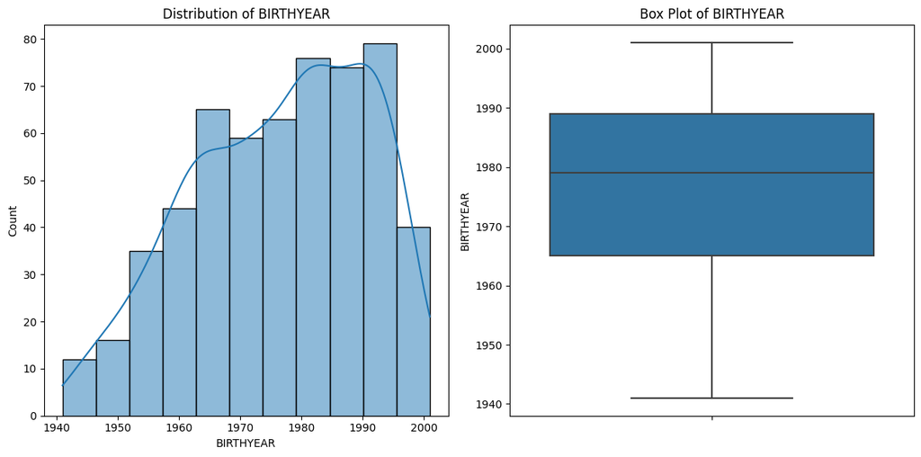

```
Statistics for BIRTHYEAR:
Count: 563
Missing: 1
Mean: 1976.48
Median: 1979.00
Std: 14.29
Min: 1941.00
Max: 2001.00
```

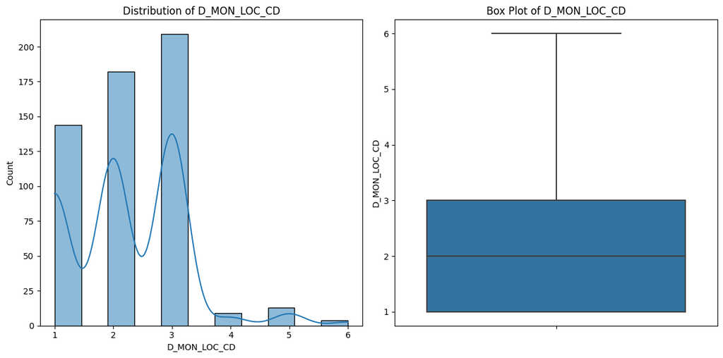

```
Statistics for D_MON_LOC_CD:
Count: 561
Missing: 3
Mean: 2.25
Median: 2.00
Std: 0.98
Min: 1.00
Max: 6.00
```

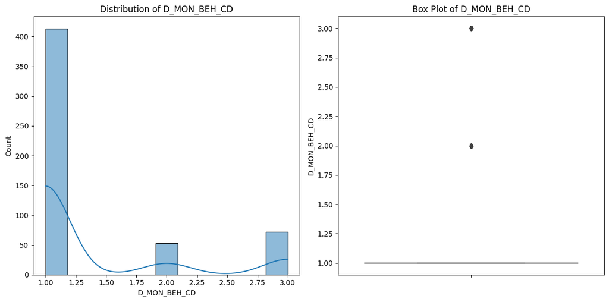

```
Statistics for D_MON_BEH_CD:
Count: 538
Missing: 26
Mean: 1.37
Median: 1.00
Std: 0.71
Min: 1.00
Max: 3.00
```

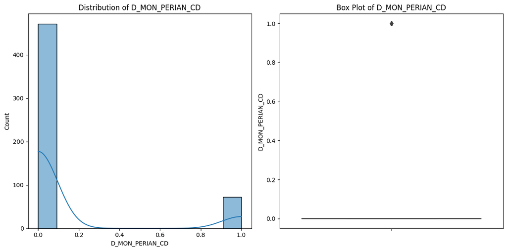

```
Statistics for D_MON_PERIAN_CD:
Count: 543
Missing: 21
Mean: 0.13
Median: 0.00
Std: 0.34
Min: 0.00
Max: 1.00
```

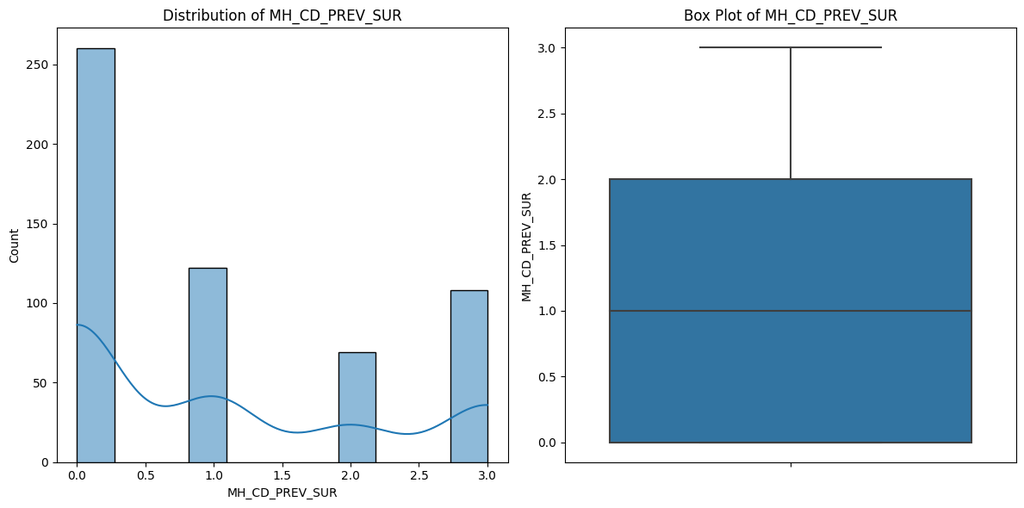

```
Statistics for MH_CD_PREV_SUR:
Count: 559
Missing: 5
Mean: 1.04
Median: 1.00
Std: 1.17
Min: 0.00
Max: 3.00
```

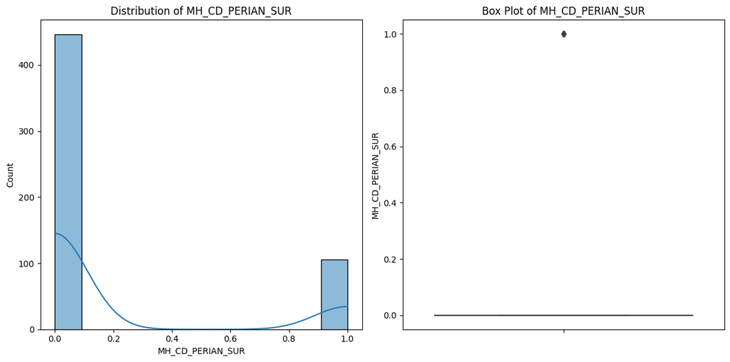

```
Statistics for MH_CD_PERIAN_SUR:
Count: 552
Missing: 12
Mean: 0.19
Median: 0.00
Std: 0.39
Min: 0.00
Max: 1.00
```

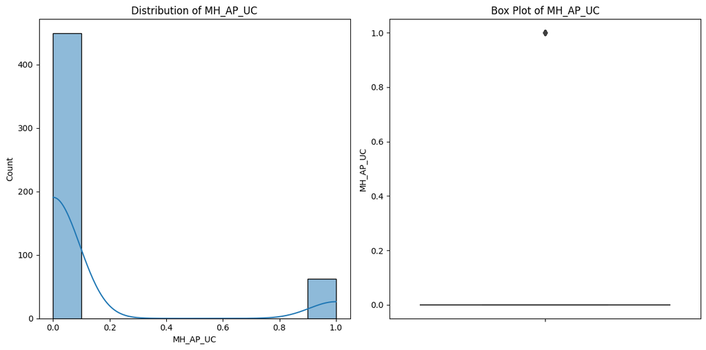

```
Statistics for MH_AP_UC:
Count: 511
Missing: 53
Mean: 0.12
Median: 0.00
Std: 0.33
Min: 0.00
Max: 1.00
```

[73 more figures not shown]

```python
import pandas as pd
import numpy as np
import matplotlib.pyplot as plt
import seaborn as sns
from scipy import stats

def analyze_categorical_variables(df):
    """Analyze categorical variables with improved error handling"""
    categorical_cols = df.select_dtypes(include=['object', 'category']).columns

    for col in categorical_cols:
        if df[col].dropna().empty:
            print(f"Skipping {col} - No non-null values")
            continue

        # Value counts and percentages
        value_counts = df[col].value_counts()
        value_percentages = df[col].value_counts(normalize=True) * 100

        # Only create visualization if there are values to plot
        if len(value_counts) > 0:
            plt.figure(figsize=(12, 6))

            # Create bar plot with explicit values
            ax = plt.subplot(1, 1, 1)
            bars = ax.bar(range(len(value_counts)), value_counts.values)

            # Customize the plot
            plt.title(f'Distribution of {col}')
            plt.xlabel(col)
            plt.ylabel('Count')

            # Add value labels on top of bars
            for i, bar in enumerate(bars):
                height = bar.get_height()
                ax.text(bar.get_x() + bar.get_width()/2., height,
                       f'{height:,}\n({value_percentages[i]:.1f}%)',
                       ha='center', va='bottom')

            # Set x-axis labels
            plt.xticks(range(len(value_counts)), value_counts.index,
                      rotation=45, ha='right')

            plt.tight_layout()
            #plt.savefig(f'icc_analysis/{col}_distribution.png')
            plt.show()

        # Print summary statistics
        print(f"\nAnalysis for {col}:")
        print(f"Missing values: {df[col].isnull().sum()} ({df[col].isnull().mean()*100:.2f}%)")
        print(f"Number of unique values: {df[col].nunique()}")
        print("\nValue counts:")
        for val, count, pct in zip(value_counts.index, value_counts, value_percentages):
            print(f"{val}: {count} ({pct:.2f}%)")

def analyze_numeric_variables(df):
    """Analyze numeric variables with improved error handling"""
    numeric_cols = df.select_dtypes(include=['int64', 'float64']).columns

    for col in numeric_cols:
        if df[col].dropna().empty:
            print(f"Skipping {col} - No non-null values")
            continue

        plt.figure(figsize=(12, 6))

        # Distribution plot
        plt.subplot(1, 2, 1)
        sns.histplot(data=df, x=col, kde=True)
        plt.title(f'Distribution of {col}')

        # Box plot
        plt.subplot(1, 2, 2)
        sns.boxplot(y=df[col].dropna())
        plt.title(f'Box Plot of {col}')

        plt.tight_layout()
        #plt.savefig(f'icc_analysis/{col}_distribution.png')
        plt.show()

        # Calculate statistics
        stats_dict = {
            'Count': df[col].count(),
            'Missing': df[col].isnull().sum(),
            'Mean': df[col].mean(),
            'Median': df[col].median(),
            'Std': df[col].std(),
            'Min': df[col].min(),
            'Max': df[col].max()
        }

        print(f"\nStatistics for {col}:")
        for stat, value in stats_dict.items():
            print(f"{stat}: {value:.2f}" if isinstance(value, float) else f"{stat}: {value}")

def analyze_data(df):
    """Main analysis function"""


    print("Starting analysis...")
    print("\nAnalyzing numeric variables...")
    analyze_numeric_variables(df)

    print("\nAnalyzing categorical variables...")
    analyze_categorical_variables(df)

    print("\nAnalysis complete. Results saved in 'icc_analysis' directory.")

# Run the analysis
analyze_data(icc_clean)
```